# STARS_SSN_V4

Luke Vawter

2/23/2022

# -Introduction-

This is a modification of STARS_SSN_V2(which ran to completion but gave bad output). This is the first version to run to completion and give full outputs, including predictions.This should be the template for ssn runs moving forward.

There is sample code for running an SSN prediction model at:

https://www.fs.fed.us/rm/boise/AWAE/projects/NorWeST/downloads/NorWeST%20SSN%20example%20code.R

When sample code is referenced here, this is what is being referred to

# -Initial Set-up-

### Install Packages and Set Data Path

the SSN library is imported. A path for our the SSN data is set. This data is an output from Andrea Nagel’s run of STARS.

```r
library(SSN)
library(dplyr)
library(lubridate)
 data_path ='data/ICPRB4/lsn.ssn'
```

### Create Custom Functions

functions are created for standardizing variables and predictions, that will be used later. These have been pulled directly from the sample code.

```r
# Function to standardize variables
stand <- function(x) { (x-mean(x))/(2*sd(x))}

# Function to standardize a prediction dataset based on the fitting dataset
stdpreds <- function(newset,originalset) {
    xnames <- colnames(newset)
    sx <- matrix(rep(NA,ncol(newset)*nrow(newset)),nrow=nrow(newset))
    for(i in 1:ncol(newset)) {
        var <- with(originalset,get(xnames[i]))
        sx[,i] <- (newset[,i]-mean(var))/(2*sd(var))
        }
    colnames(sx) <- colnames(newset)
    return(sx)
}
```

### Import Data to SSN Object

import the data from our data to an ssn object

```r
test.ssn <- importSSN(data_path, predpts = "preds", o.write = T)
```

### Clean Data

from our ssn object we grab a dataframe and push the dataframe back into he ssn object. We also convert DATE value to julian. We also remove two covariates (AREAKM2 and TOTDAKM2) that were causing the glmssn function to fail

```r
test_temp.df<- getSSNdata.frame(test.ssn)

test_temp.df<- select(test_temp.df, -AREAKM2, -TOTDAKM2)

test_temp.df <- test_temp.df %>%
  mutate(DATE_ = as.Date(test_temp.df$DATE_, "%Y-%m-%d")) %>%
  mutate(DATE_ =  yday(test_temp.df$DATE_))

test.ssn <- putSSNdata.frame(test_temp.df,test.ssn,"Obs")
test_temp.df<- getSSNdata.frame(test.ssn)
```

Save the ssn dataframe to our data folder for reference

```r
write.csv(test.ssn,"data/ICPRB4/test_ssn.csv")
```

# -Run-

### Distance Matrix

createDistMat function creates a distance matrix. Memory limits for R needed to be increased to run. I set it to 200000 MB, and that was sufficient for our data. Predpts are named preds in our lsn.ssn file and so are given the value ‘preds’.

```r
#had to check memory and then adjust memory limit
memory.size()
```

```
## [1] 316.8
```

```r
memory.limit()
```

```
## [1] 32495
```

```r
memory.limit(size=200000)
```

```
## [1] 2e+05
```

```r
#dist_mat_test =
createDistMat(test.ssn, o.write=T, predpts = 'preds', amongpreds=T)
# ssn, predpts = NULL, o.write = FALSE, amongpreds = FALSE)
```

### Torgegrams

create Torgegram

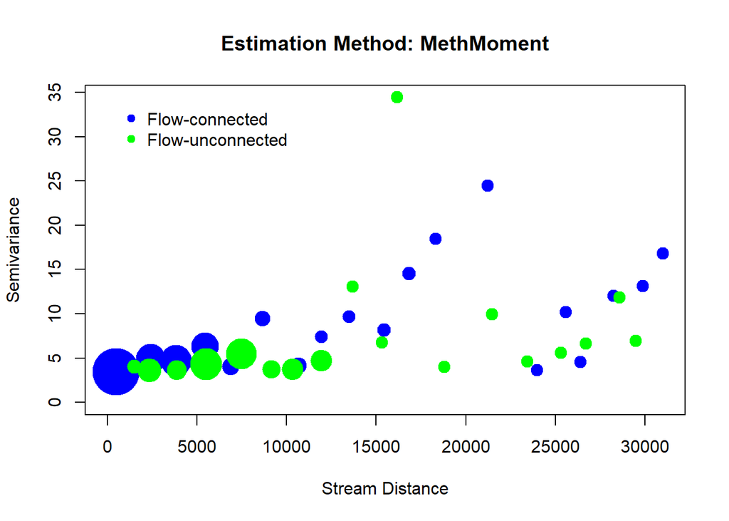

```r
# Create raw torgegram
test_torg <- Torgegram(test.ssn,"TWAT",nlag=20)
plot(test_torg)
```

plot Torgegram for connected and unconnected(should be dipslayed in kilometers)and save both as jpegs

```r
jpeg("data/ICPRB4/torgegram_flow_connected.jpg")
plot.Torgegram(test_torg, sp.relationship = c("fc"), xlab = "Stream Distance (meter)")
dev.off()
```

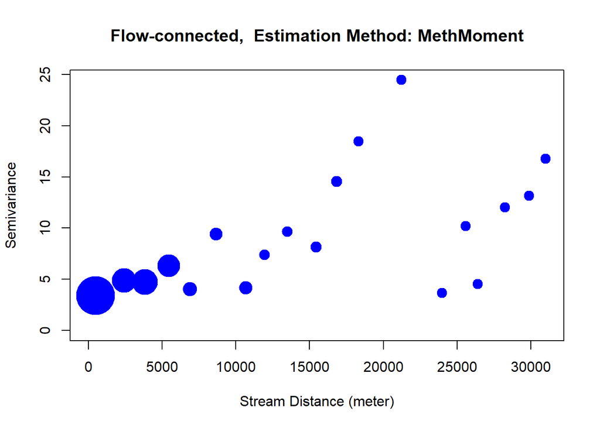

```r
plot.Torgegram(test_torg, sp.relationship = c("fc"), xlab = "Stream Distance (meter)")
```

```r
jpeg("data/ICPRB4/torgegram_flow_unconnected.jpg")
plot.Torgegram(test_torg, sp.relationship = c("fu"), xlab = "Stream Distance (meter)")
dev.off()
```

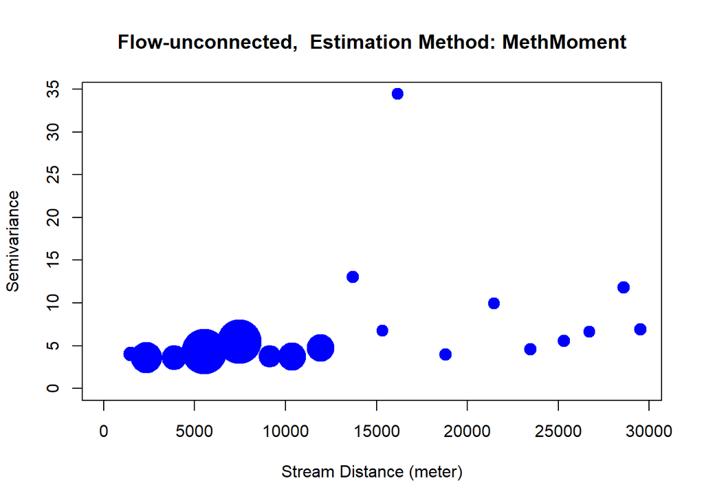

```r
plot.Torgegram(test_torg, sp.relationship = c("fu"), xlab = "Stream Distance (meter)")
```

Extract dataframe and fit basic aspatial model with un-standardized predictors

```r
test.df<- getSSNdata.frame(test.ssn)

test.lm <- lm(TWAT ~ TAIR + PRECIP + SOLRAD + FLOW + ELEV + SLOPE + PURB16 + PFOR16 + PAG16 + PWSTOR16 + PCAN14 + PIMP14 + PEWET + PFWET + PRWET + PHYDA, data=test.df)
summary(test.lm)
```

```
##
## Call:
## lm(formula = TWAT ~ TAIR + PRECIP + SOLRAD + FLOW + ELEV + SLOPE +
##     PURB16 + PFOR16 + PAG16 + PWSTOR16 + PCAN14 + PIMP14 + PEWET +
##     PFWET + PRWET + PHYDA, data = test.df)
##
## Residuals:
##     Min      1Q  Median      3Q     Max
## -7.3289 -0.7392  0.0320  0.7834  9.0592
##
## Coefficients:
##              Estimate Std. Error t value Pr(>|t|)
## (Intercept) 10.624154   5.633376   1.886 0.059408 .
## TAIR         0.426122   0.008702  48.967  < 2e-16 ***
## PRECIP       0.018318   0.002778   6.593 5.14e-11 ***
## SOLRAD       0.003115   0.006389   0.488 0.625918
## FLOW        -0.058595   0.026864  -2.181 0.029255 *
## ELEV         0.003878   0.003428   1.131 0.258037
## SLOPE        4.776947  12.524634   0.381 0.702932
## PURB16       0.041672   0.043027   0.969 0.332870
## PFOR16       0.113144   0.041706   2.713 0.006710 **
## PAG16       -0.042122   0.051169  -0.823 0.410470
## PWSTOR16    -0.034176   0.082837  -0.413 0.679950
## PCAN14      -0.095887   0.017924  -5.350 9.52e-08 ***
## PIMP14       0.075423   0.018046   4.179 3.01e-05 ***
## PEWET        0.020917   0.006009   3.481 0.000507 ***
## PFWET        0.010400   0.001706   6.096 1.24e-09 ***
## PRWET       -0.008213   0.002323  -3.535 0.000415 ***
## PHYDA        0.007502   0.014264   0.526 0.598944
## ---
## Signif. codes:  0 '***' 0.001 '**' 0.01 '*' 0.05 '.' 0.1 ' ' 1
##
## Residual standard error: 1.357 on 2792 degrees of freedom
## Multiple R-squared:  0.6365, Adjusted R-squared:  0.6344
## F-statistic: 305.6 on 16 and 2792 DF,  p-value: < 2.2e-16
```

### Standardize Covariates

Standardize continuous covariates and add factor for year The following steps are taken from sample code and adapted to fit our data indices/covariates

```r
# Standardize continuous covariates and add factor for year
continuous <- test.df[,c(13:28)] #[,c(14:29)]
cont.s <- apply(continuous,2,stand)
colnames(cont.s) <- c("TAIR","PRECIP","SOLRAD","FLOW","ELEV","SLOPE","PURB16","PFOR16","PAG16", "PWSTOR16", "PCAN14", "PIMP14", "PEWET", "PFWET", "PRWET", "PHYDA")

test.df.s <- data.frame(test.df,cont.s)

test.df.s$datef <- factor(test.df.s$DATE_)

test_master <- putSSNdata.frame(test.df.s,test.ssn,"Obs")
```

esttable is constructed and saved

```r
library(tibble)
testAe <- summary(test.lm)$coefficients

backtrans <- testAe[-c(1),1:2]/(2*sapply(continuous,sd))

esttable <- cbind(rbind(testAe[1,1:2],backtrans[1:15,],testAe[10,1:2]),testAe)

#fixes row names by overwriting them
rownames(esttable) <- rownames(testAe)

write.csv(esttable,"data/ICPRB4/test_aspatialestimates.csv")

# # Aspatial performance
predictA <- predict(test.lm)
sqrt(mean((predictA-test.df.s$TWAT)^2))
```

```
## [1] 1.352627
```

```r
# # print(predictA)
# # 1.885
```

### Examine correlations

Generate a correlation plot and save it to data folder

```r
# Examine correlations
library(ellipse)
```

```r
library(corrplot)
#color for legend
COL1(sequential = c("Oranges", "Purples", "Reds", "Blues", "Greens",
                    "Greys", "OrRd", "YlOrRd", "YlOrBr", "YlGn"), n = 200)
```

[output not shown]

```r
cor1 = cor(cont.s)
jpeg("data/ICPRB4/corrplot.jpg")
corrplot(cor1, type='lower',col=COL1())
dev.off()
```

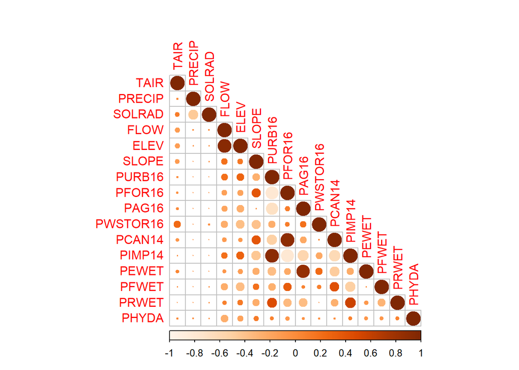

```r
corrplot(cor1, type='lower',col=COL1())
```

### Standardize Preds

Standardize preds based on obs and add factor for year- pred Code is adapted from sample code to fit our data indices/covariates and output is saved

```r
testpreddf <- getSSNdata.frame(test.ssn, "preds")

contpred <- testpreddf[,c(13:28)]
contpred.s <- stdpreds(contpred,continuous)

 colnames(contpred.s) <-
c("TAIR", "PRECIP", "SOLRAD", "FLOW", "ELEV", "SLOPE", "PURB16", "PFOR16", "PAG16", "PWSTOR16", "PCAN14", "PIMP14", "PEWET", "PWFET", "PRWET", "PHYDA")#, "AREAKM2","TOTDAKM2")
testpreddf.s <- data.frame(testpreddf,contpred.s)
testpreddf.s$datef <- factor(testpreddf.s$DATE_)
test_master <- putSSNdata.frame(testpreddf.s,test_master,"preds")

testmaster <- getSSNdata.frame(test_master, "preds")
write.csv(testmaster,"data/ICPRB4/testmaster.csv")
```

# -Model 1-

“The glmssn function fits a spatial linear model (Equation 3) to a SpatialStreamNetwork object with a covariance structure”

The glmssn function can take hours to run.

“This limits the size of data sets that can be fit by the glmssn function, and for most computing systems today we suggest sample sizes of less than 1000 observations.” https://www.fs.fed.us/rm/boise/AWAE/projects/SSN_STARS/downloads/SSN/SSNvignette2014.pdf page21

Also, we track glmssn run time(elapsed variable), as recommended by sample code

### GLMSSN

```r
starttime <- Sys.time() # not necessary; just for timing longer runs
test_1 <- glmssn(formula = TWAT ~ TAIR + PRECIP + SOLRAD + FLOW + ELEV + SLOPE + PURB16 + PFOR16 + PAG16 + PWSTOR16 + PCAN14 + PIMP14 + PEWET + PFWET + PRWET + PHYDA, ssn.object = test_master, EstMeth= "ML", family="gaussian", CorModels = c("locID","datef","Exponential.tailup","Exponential.taildown","Exponential.Euclid"), addfunccol = "afvArea")

elapsed <- Sys.time()-starttime # See above note
```

### Extract predictions/ Leave-one-out cross validation predictions

```r
# Extract predictions/ Leave-one-out cross validation predictions
test_1r <- residuals(test_1, cross.validation=T)
test_1r.df <- getSSNdata.frame(test_1r)
```

### Generate Torgegram

generate a Torgegram of fitted model and save

```r
# Torgegram of fitted model residuals
test_1t <- Torgegram(test_1r,"_resid.crossv_",nlag=20)
jpeg("data/ICPRB4/model_torgegram_full.jpg")
plot(test_1t, main= "Model1 Residuals Torgegram")
dev.off()
```

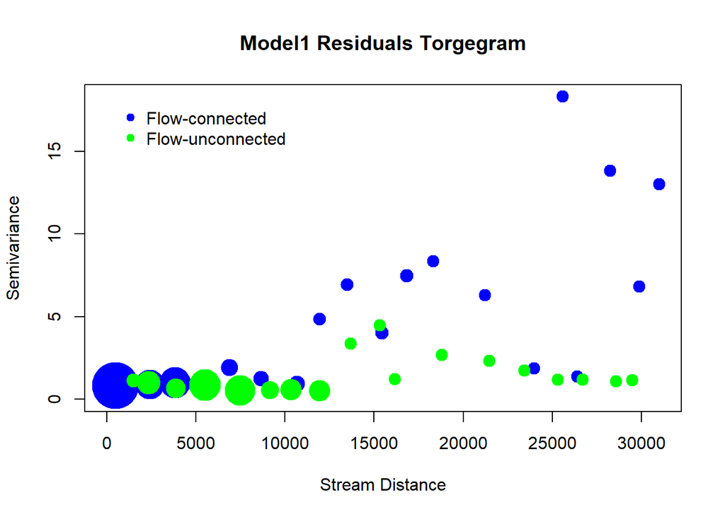

```r
plot(test_1t, main= "Model1 Residuals Torgegram")
```

```r
jpeg("data/ICPRB4/model_1_flow_connected.jpg")
plot.Torgegram(test_1t, sp.relationship = c("fc"), xlab = "Stream Distance (meter)")
dev.off()
```

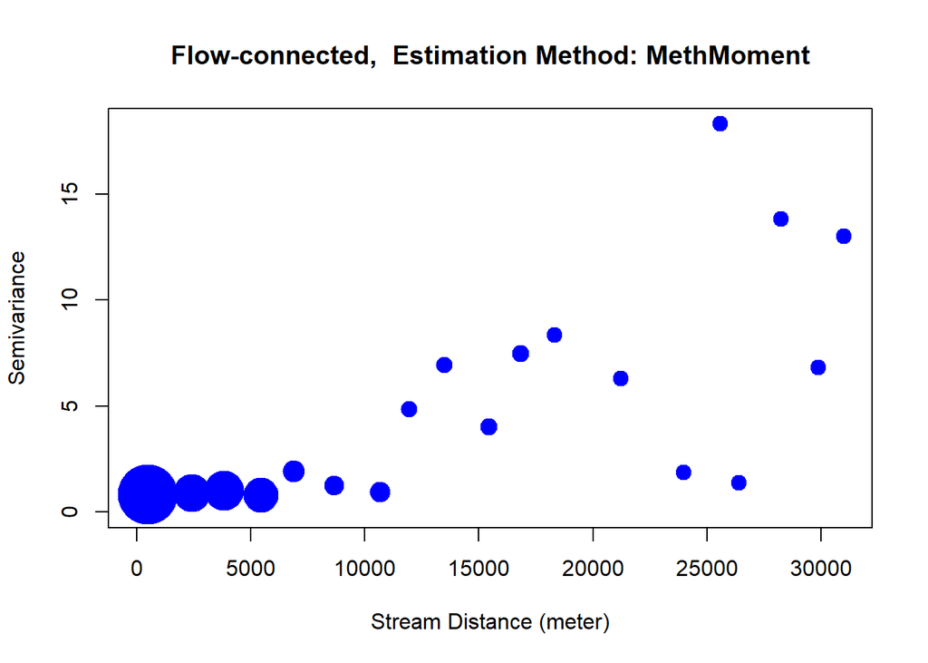

```r
plot.Torgegram(test_1t, sp.relationship = c("fc"), xlab = "Stream Distance (meter)")
```

```r
jpeg("data/ICPRB4/model_1_flow_unconnected.jpg")
plot.Torgegram(test_1t, sp.relationship = c("fu"), xlab = "Stream Distance (meter)")
dev.off()
```

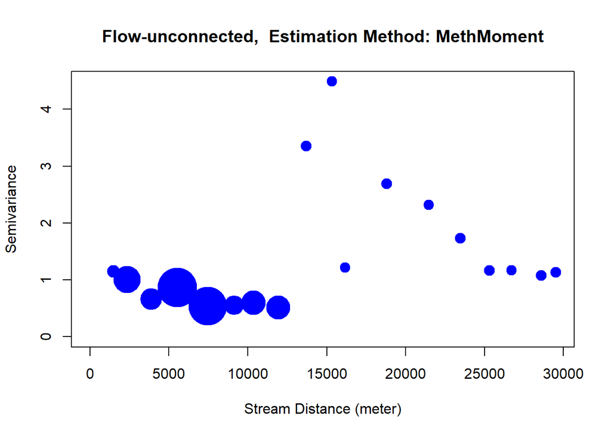

```r
plot.Torgegram(test_1t, sp.relationship = c("fu"), xlab = "Stream Distance (meter)")
```

```r
#Root mean squared error (RMSE) of cross-validated predictions
sqrt(mean((test_1r.df[,"_CrossValPred_"]-test_1r.df$obsval)^2))
```

```
## [1] 1.007884
```

```r
# 0.969


#RMSE of fixed effects only
sqrt(mean((test_1r.df[,"_fit_"]-test_1r.df$obsval)^2))
```

```
## [1] 1.483133
```

```r
# 1.935


# Null RMSE
sqrt(mean((test_1r.df$obsval-mean(test_1r.df$obsval))^2))
```

```
## [1] 2.243514
```

```r
# 2.996

#Pseudo-r2 of cross-validated predictions.
cor(test_1r.df$obsval,test_1r.df[,"_CrossValPred_"])^2
```

```
## [1] 0.7982569
```

```r
# 0.895
```

### Estimates

Get parameter estimates, back-transform, and save estimates as model_1_estimates

```r
test_1e <- summary(test_1)$fixed.effects.estimates

m1_backtrans <- test_1e[-c(0,10),2:3]/(2*sapply(continuous[,c(1:7,9:11)],sd))#continuous[,c

esttable <- cbind(test_1e[,1],rbind(test_1e[1,2:3],m1_backtrans[1:15,],test_1e[10,2:3]),test_1e[,2:5])

write.csv(esttable,"data/ICPRB4/model_1_estimates.csv")
```

# -Predictions-

### split preds

sample code recommends data can be split using the splitPredictions if the data has multiple prediction point files in .ssn folder. We only have preds, and a managable dataset size. Below code has been commmented out.

```r
# library(SSN)
# test_1$ssn.object <- splitPredictions(test_1$ssn.object, "preds-1",chu
# nksof=10000)
# # splitPredictions
# print(test_1$ssn.object)
```

### Extract prediction data frames

```r
test1p1 <- predict(test_1,predpointsID = "preds")

# # Extract prediction data frames
pred1df <- getSSNdata.frame(test1p1,"preds")
```

### reassemble predictions

Process of reassembling data will look something like this. This has been commented out but left in for reference.

```r
# Reassemble the pieces into one batch.
#not required since wasn't split

# allpreds <- rbind(pred1df[,c("OBSPREDID","STREAM_AUG","STREAM_AUG.predSE")],pred2df[,c("OBSPREDID","STREAM_AUG","STREAM_AUG.predSE")],pred3df[,c("OBSPREDID","STREAM_AUG","STREAM_AUG.predSE")],pred4df[,c("OBSPREDID","STREAM_AUG","STREAM_AUG.predSE")],pred5df[,c("OBSPREDID","STREAM_AUG","STREAM_AUG.predSE")],pred6df[,c("OBSPREDID","STREAM_AUG","STREAM_AUG.predSE")],pred7df[,c("OBSPREDID","STREAM_AUG","STREAM_AUG.predSE")])
# colnames(allpreds) <- c("OBSPREDID","predtemp","predtempse")
```

### Export Predictions

```r
library(foreign)

write.csv(pred1df,"data/ICPRB4/model_1_predictions.csv",row.names=F)
write.dbf(pred1df,"data/ICPRB4/model_1_predictions.dbf")
```

### Compare Predictions

```r
# predobs <- data.frame(test_1r.df$OBSPREDID,test_1r.df[,"_CrossValPred_"],test_1r.df$obsval)
#
# colnames(predobs) <- c("obspredid","predicted","observed")
#
# write.csv(predobs,"data/ICPRB4/model_1_prediction_observations.csv",row.names=F)
#
# test_obs <- test_1r.df$OBSPREDID
#
# print(test_1r.df[,"_CrossValPred_"])
```

# -Outputs-

### Estimate Table

```r
print(esttable)
```

```
##    test_1e[, 1]      Estimate      std.err      Estimate      std.err
## 1   (Intercept) -2.018249e+01 3.206771e+01 -20.182493554 32.067709514
## 17         TAIR -3.256186e+00 6.686665e-01   0.336466665  0.007947509
## 2        PRECIP  1.622268e-02 2.684755e-04   0.012623413  0.002760740
## 3        SOLRAD  1.389481e-03 1.124507e-03   0.005658406  0.006636266
## 4          FLOW  6.833800e-04 2.653115e-04  -0.026833781  0.100695512
## 5          ELEV -3.923420e-04 1.624593e-02   0.002166501  0.012785370
## 6         SLOPE  2.266143e-01 6.164443e-04  62.098020392 61.201247704
## 7        PURB16  1.294850e+00 6.736525e+00   0.251944239  0.277780954
## 8        PFOR16  8.510949e-03 3.354831e-02   0.224001176  0.293491319
## 9         PAG16  9.124034e-02 4.291195e-03   0.277542006  0.293578430
## 11     PWSTOR16  2.459176e-02 4.142246e+01   0.615116423  0.396011249
## 12       PCAN14  1.796811e-02 1.788058e-03   0.111369960  0.085751173
## 13       PIMP14  1.044627e-02 2.374620e-03   0.216660930  0.070294382
## 14        PEWET  1.655949e-03 1.166207e-02   0.015044271  0.028631160
```

[output cut: 21 more lines]

### Predictions

```r
print(pred1df)
```

[output not shown]

[output cut: 13322 more lines]

### Comparison

```r
# print(predobs)
```